# Practical Class 6: Biodiversity changes

Author

François Leroy

**Content of the workshop of today**

We will continue to work with the North American BBS that we worked with already. Last week, we assessed several metrics of biodiversity for the year 2019. However, we can wonder: how has bird biodiversity changed through time (*e.g.* from 1980 to 2021)?

To answer this question, we need **time-series** *i.e.*, data which have been harvested for several years at the same location. This is the case of the BBS: each road has been visited once a year for a very long time. Today, we will work with data from 2000 to 2021 and assess how has biodiversity changed through this period for the different BBS roads.

Also, when working with time-series, one thing to consider is how the repeated samples have been made through the years. Were they sampled for the same amount of time? By the same number of volunteers…? This is what is often called in ecology the *sampling effort* or the *study design*. Fortunately, the BBS data collection is standardized, which means that the volunteers have to follow a protocol when counting the birds. Thus, we can compare the data through time without having to account for the sampling effort.

# Assessing temporal change of diversity

There are two ways to assess changes of biodiversity:

1. We can simply measure biodiversity (for instance with species richness) and then see how this metric has changed through time. This is called a **temporal trend**.
2. We can use metrics which are representing temporal dynamic of biodiversity. Here, we will study the two metrics responsible of the change of species richness: *colonization* and *extinction*.

# Temporal changes of species richness

## Using simple linear regression

We will first see how species richness has changed through time for the different BBS roads.

```r
rm(list = ls())
## A bit of data management. This is the same as we did last week.
library(readr)
library(tidyr)
library(dplyr)
## Get the file names
file_list <- list.files("data/50-StopData/1997ToPresent_SurveyWide/",
                        full.names = T)
## Create the dataframe that will contain the data
species <- data.frame()
## Loop over each file
for(i in 1:length(file_list)){
  ## Load the file and temporary store it
  d <- read_csv(file_list[i])
  ## Bind to the species dataframe
  species <- rbind(species, d)
  ## Remove the temporary data
  rm(d)
}

## Also, we will keep only the roads which have data in both 2000 and 2021
species <-
  species %>%
  group_by(CountryNum, StateNum, Route) %>%
  filter(any(Year == 2000)) %>%
  filter(any(Year == 2021)) %>%
  filter(Year %in% c(2000:2021)) %>%
  ungroup()
```

```r
## Unlike last week, today we will work on the entire dataset, and not only year 2019.
## Let's compute species richness for each road and each year using the RouteDataID column.
species_richness <-
  species %>%
  group_by(RouteDataID) %>%
  summarize(sr = length(unique(AOU)),        ## Compute species richness
            CountryNum = unique(CountryNum), ## Keep the route info
            StateNum = unique(StateNum),     ## Keep the route info
            Route = unique(Route),           ## Keep the route info
            Year = unique(Year))             ## Keep the year
```

Let’s represent the values of species richness through time for a single route. It is important to note that the unique identifier of a road is composed by the combination of the three columns: `CountryNum + StateNum + Route`.

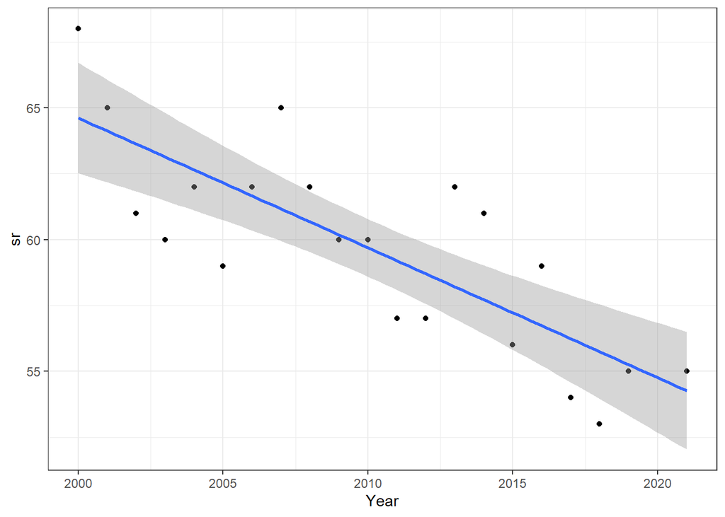

```r
library(ggplot2)
## Let's pick up randomly one road ####
species_richness %>%
  filter(CountryNum == 840,
         StateNum == "35",
         Route == "005") %>%
  #### and plot the value of species richness against time
  ggplot(aes(x = Year, y = sr))+
  geom_point()+
  geom_smooth(method = "lm")+
  theme_bw()
```

Well, it seems like there is a linear relationship between species richness and time isn’t it? If you remember the class of last week, you know that we can fit a simple linear regression to explain how species richness is *“driven”* by the time (in other words how it behaves through time):

$$SR = \beta_1t + \beta_0$$

**Try to explain how** $\beta_1$ **and** $\beta_0$ **link the species richness with time**

Hereafter, we will fit simple linear regressions of species richness as a function of time for each road of the BBS.

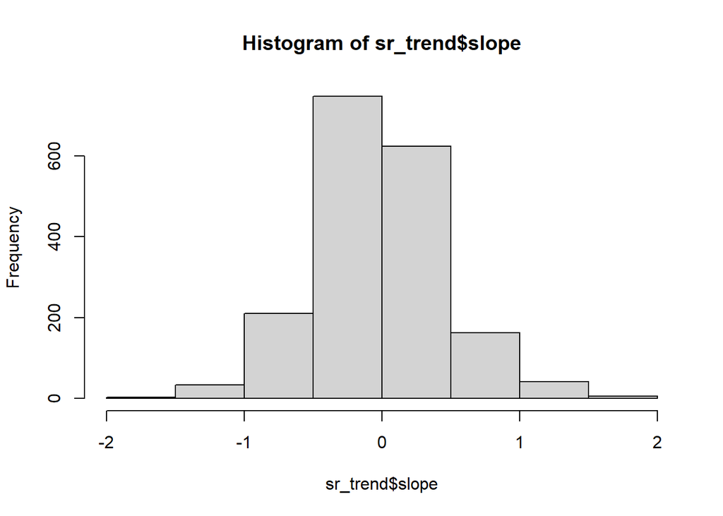

```r
## Now let's fit a linear regression between species richness and time for each road.
## We could use a for loop but R as a cool function: do()
sr_trend <-
  species_richness %>%
  group_by(CountryNum, StateNum, Route) %>%  ## those 3 columns represent the route id
  do({
      mod <- lm(sr ~ Year, data = .)                               #### fit the linear model
      data.frame(slope = coef(mod)[2],                             #### extract the slope
                 intercept = coef(mod)[1],                         #### extract the intercept
                 pval = (summary(mod)$coefficients[2,"Pr(>|t|)"])) #### extract the p-value

    })

# We can display the distribution of the slope values using
hist(sr_trend$slope)
```

**What can we say about the trends of species richness from 2000 to 2021 for the BBS roads?**

**Using the script of last week, display on a map the BBS roads with the color indicating the temporal trend of species richness (exemple below)** *Hint:* in order to set the color gradient from red to blue passing by white, you should use the function `scale_color_gradient2()`. Use `?scale_color_gradient2()` to know more.

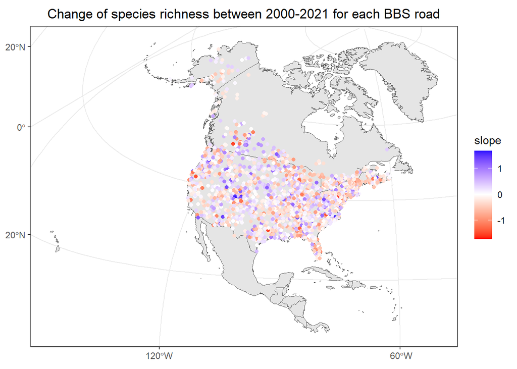

## Using polynomial regression

Polynomial regression is a specific case of a linear regression. Even though the final function is not linear, the coefficients of each order of $x$ are linear:

$$y = \beta_1x_1 + \beta_2x_1^2 + \beta_3x_1^3 \ldots \beta _nx_1^n + \beta_0$$
Let’s use a time series of another random road:

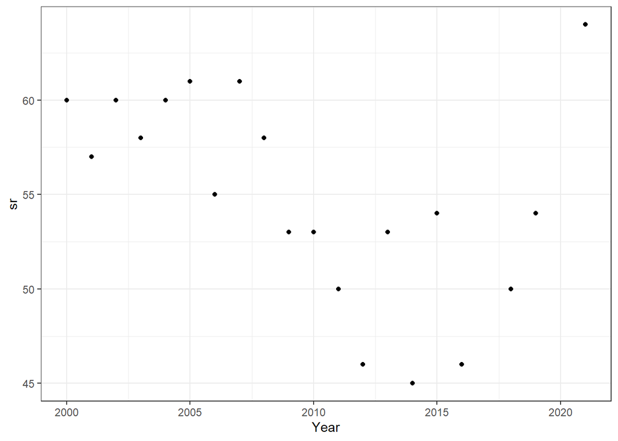

```r
species_richness %>%
  filter(CountryNum == 840,
         StateNum == "25",
         Route == "025") %>%
  #### and plot the value of species richness against time
  ggplot(aes(x = Year, y = sr))+
  geom_point()+
  # geom_smooth(method = "lm")+
  theme_bw()
```

As you can see, this time the relationship does not really seem linear. So let’s fit polynomial regressions (*i.e.* quadratic, cubic…) and see how the regressions look like.

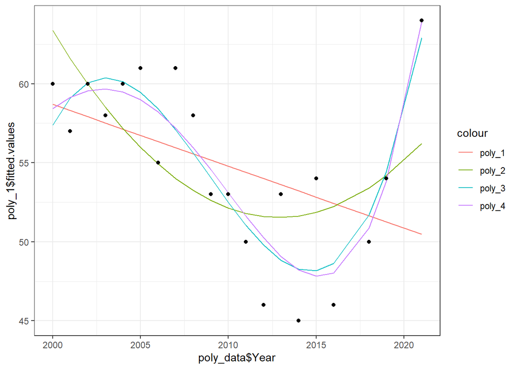

```r
poly_data <-
  species_richness %>%
  filter(CountryNum == 840,
         StateNum == "25",
         Route == "025")

poly_1 <- lm(sr ~ poly(Year, 1), data = poly_data)
poly_2 <- lm(sr ~ poly(Year, 2), data = poly_data)
poly_3 <- lm(sr ~ poly(Year, 3), data = poly_data)
poly_4 <- lm(sr ~ poly(Year, 4), data = poly_data)

ggplot()+
  geom_line(aes(x = poly_data$Year, y = poly_1$fitted.values, color = "poly_1"))+
  geom_line(aes(x = poly_data$Year, y = poly_2$fitted.values, color = "poly_2"))+
  geom_line(aes(x = poly_data$Year, y = poly_3$fitted.values, color = "poly_3"))+
  geom_line(aes(x = poly_data$Year, y = poly_4$fitted.values, color = "poly_4"))+
  geom_point(aes(x = Year, y = sr), data = poly_data)+
  theme_bw()
```

You can see that the higher the order of the polynomial, the higher the flexibility of the model.

```r
paste0("R² poly1 = ", summary(poly_1)$adj.r.squared)
```

```
[1] "R² poly1 = 0.152154474989737"
```

```r
paste0("R² poly2 = ", summary(poly_2)$adj.r.squared)
```

```
[1] "R² poly2 = 0.350569287307634"
```

```r
paste0("R² poly3 = ", summary(poly_3)$adj.r.squared)
```

```
[1] "R² poly3 = 0.707473782067586"
```

```r
paste0("R² poly4 = ", summary(poly_4)$adj.r.squared)
```

```
[1] "R² poly4 = 0.702284540611484"
```

**Look at the values of the `R²`: which polynomial regression seems to be the best?**

# Assessing colonization and extinction

We have seen that we can compute the temporal trend of a species richness by fitting a linear regression on it. However, the variation of species richness $\Delta SR$ can also be assessed as follows:

$$\Delta SR = SR_{t_2}-SR_{t_1}$$
Which is the difference in the number of species between 2 time steps. We can assess $SR_{t_1}$ and $SR_{t_2}$ by using colonization $C$, extinction $E$ and persistence $P$. We can rewrite $\Delta SR$ as:

$$\Delta SR = C + P - (E+P) = C - E$$

Let’s have a look at the colonization and extinction and how they drive $\Delta SR$

```r
## Load the colonization/extinction/persistence data
col_ext <- readRDS("data/col_ext.rds") %>% filter(ext != 0)
head(col_ext)
```

```
  CountryNum StateNum Route col ext pers year
1        124       04   002  15   5   46 2001
2        124       04   002   8  14   47 2002
3        124       04   002  11  11   44 2003
4        124       04   002  18   9   46 2004
5        124       04   002   5  19   45 2005
6        124       04   002  11   5   45 2006
```

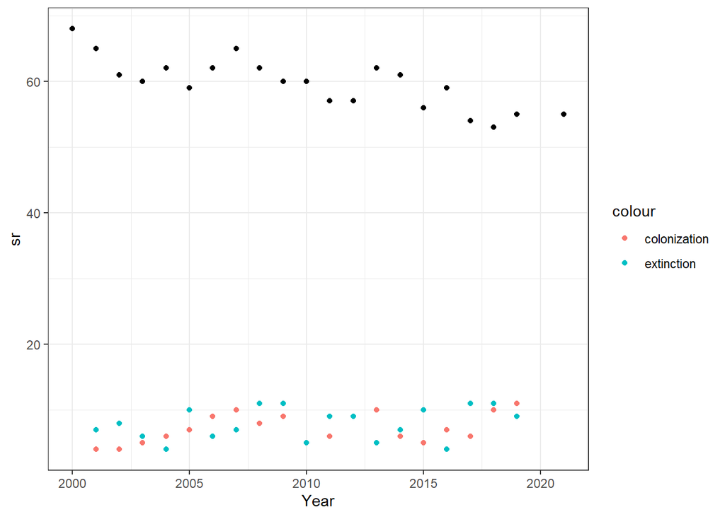

```r
## Display the temporal change of species richness along with the
## colonization and extinction for one road
ggplot()+
  geom_point(aes(x = Year, y = sr), data = species_richness %>%
               filter(CountryNum == 840,
                      StateNum == "35",
                      Route == "005"))+
  geom_point(aes(x = year, y = col,  colour = "colonization"),
             data = col_ext %>% filter(CountryNum == 840,
                                       StateNum == "35",
                                       Route == "005"))+
  geom_point(aes(x = year, y = ext, color = "extinction"),
             data = col_ext %>% filter(CountryNum == 840,
                                       StateNum == "35",
                                       Route == "005"))+
  theme_bw()
```

**Observe how colonization and extinction are linked to the species richness**

# Now it’s up to you

- **Task 1:** Assess $\Delta S$ at the scale of North America using a simple linear regression. For this, you will have to assess the number of unique species for each year in all the BBS routes (using the `group_by()` function on the `species` data). How has bird richness changed between 2000 and 2021 in the US? Plot the time series and the fitted linear regression.

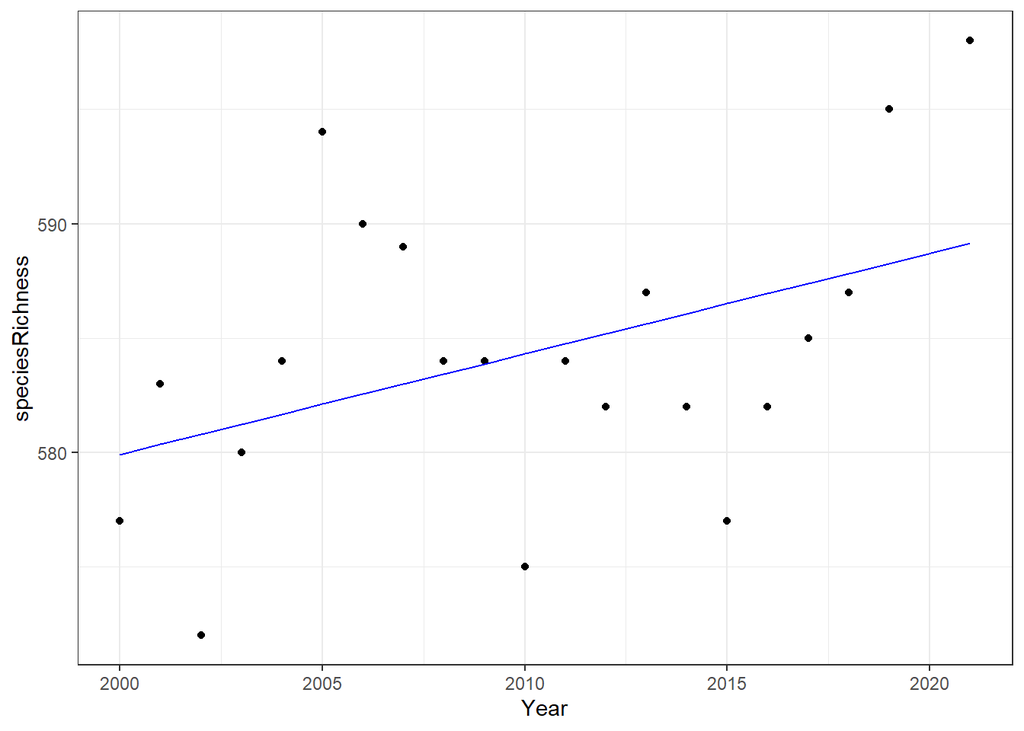

- **Task 2:** Assess $\Delta S$ at the scale of North America using a polynomial linear regressions of different order. Which polynomial fits the best the data? Plot the times series together with the different polynomial regressions.

```
[1] "R² poly1 = 0.137362340702689"
```

```
[1] "R² poly2 = 0.12412241731803"
```

```
[1] "R² poly3 = 0.466869107453869"
```

```
[1] "R² poly4 = 0.433682056848564"
```

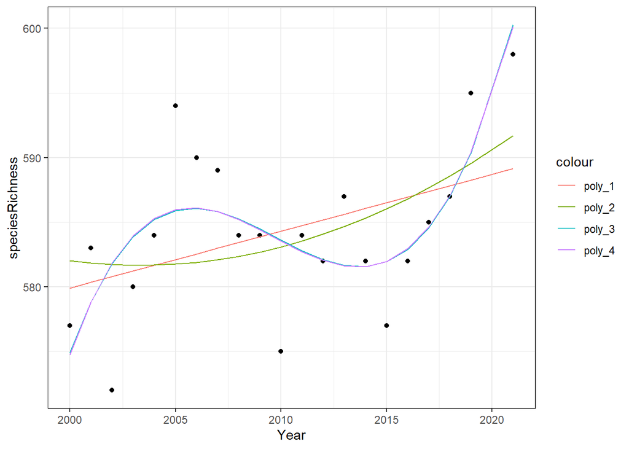

- **Task 3:** Compute the average colonization and average extinction over the time-series for each BBS route (using `group_by()` and `summarise()`). Map those 2 values.

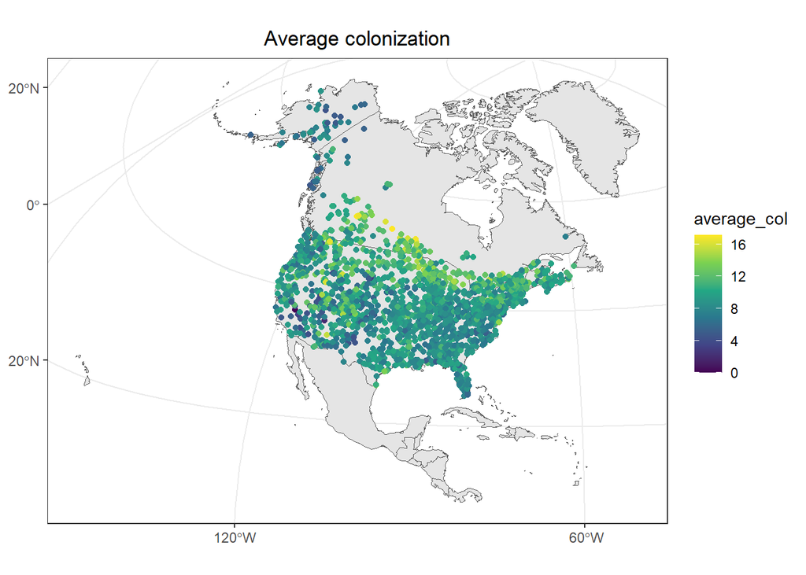

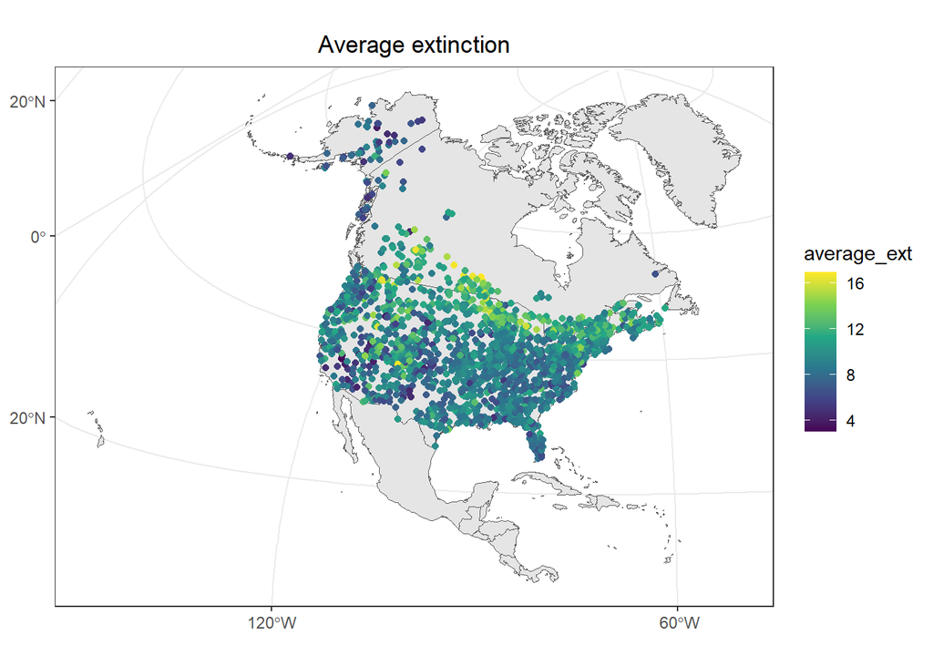

- **Task 4:** Now, for every route, assess the temporal change of colonization and extinction using linear regressions. Display those values on 2 histograms.

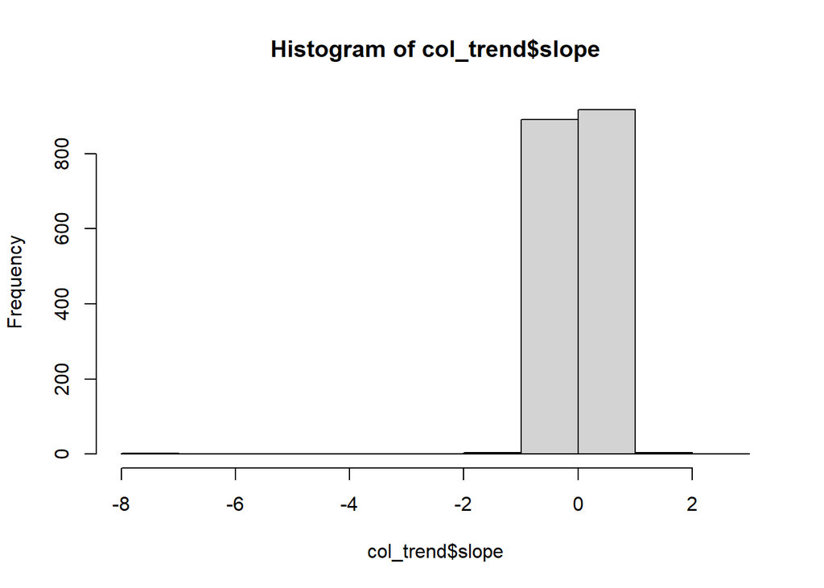

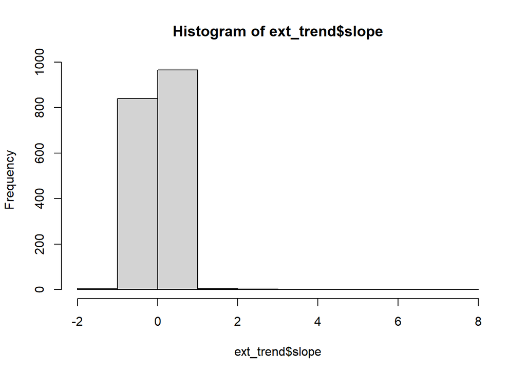